# F9_06_DISCLOSURE_STATES_FILED

States where required to file Form 990 · Code report

## Overview

**Description**

States where return filed

**Table**

`F9-P06-T00-GOVERNANCE` (one)

**Location code**

`F990-PC-PART-06-SECTION-C-LINE-17`, `F990-EZ-PART-05-LINE-41`

**Family**

`F990-PC-PART-06-SECTION-C-LINE-17`

**Data type**

text (xsd: StateType)

**Scope**

PZ

**Status**

unreviewed

5

xpaths mapped (4 observed)

2,827,771

filings with a value

2009–2024

tax years observed

6

open flags (0 errors)

## Flags

[output not shown]

## Xpaths

All mapped xpaths (under /Return/ReturnData or /Return/ReturnHeader), oldest first. Charts label each series by its xpath.

| Xpath | Form | First year | Last year | Versions | Filings | Repeats in |
| --- | --- | --- | --- | --- | --- | --- |
| IRS990/StatesWhereCopyOfReturnIsFiled | 990 | 2009 | 2012 | 18 | 260,142 | 5.5% |
| IRS990EZ/StatesWhereCopyOfReturnIsFiled | 990-EZ | 2009 | 2012 | 18 | 103,795 | 1.1% |
| IRS990/StatesWhereCopyOfReturnIsFldCd | 990 | 2013 | 2024 | 38 | 1,719,773 | 6.0% |
| IRS990EZ/StatesWhereCopyOfReturnIsFldCd | 990-EZ | 2013 | 2024 | 38 | 744,061 | 1.4% |
| IRS990/Form990PartVI/StatesWhereCopyOfReturnIsFiled | 990 |  |  |  | 0 |  |

## Coverage

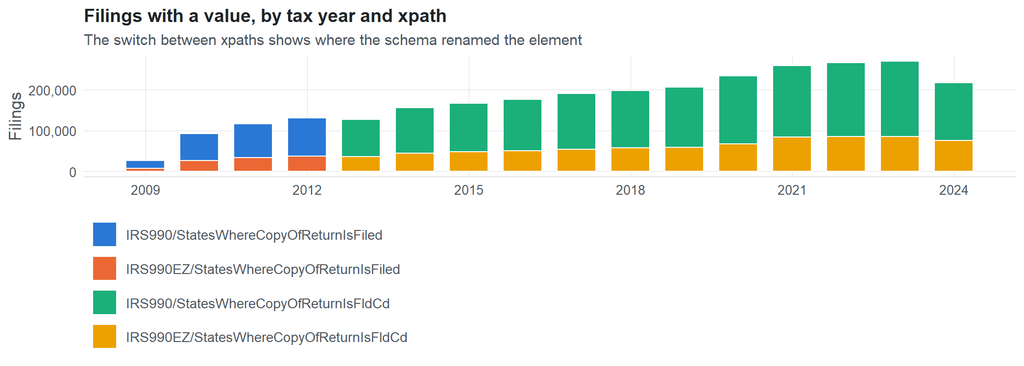

**Table view**

Table view: filings by tax year and series

| Tax year | IRS990/StatesWhereCopyOfReturnIsFiled | IRS990EZ/StatesWhereCopyOfReturnIsFiled | IRS990/StatesWhereCopyOfReturnIsFldCd | IRS990EZ/StatesWhereCopyOfReturnIsFldCd |
| --- | --- | --- | --- | --- |
| 2009 | 19,598 | 6,851 | 0 | 0 |
| 2010 | 64,979 | 26,775 | 0 | 0 |
| 2011 | 82,733 | 32,989 | 0 | 0 |
| 2012 | 92,832 | 37,180 | 0 | 0 |
| 2013 | 0 | 0 | 91,141 | 35,981 |
| 2014 | 0 | 0 | 111,707 | 44,256 |
| 2015 | 0 | 0 | 118,969 | 47,473 |
| 2016 | 0 | 0 | 126,371 | 50,255 |
| 2017 | 0 | 0 | 136,439 | 53,915 |
| 2018 | 0 | 0 | 140,147 | 57,221 |
| 2019 | 0 | 0 | 147,291 | 59,003 |
| 2020 | 0 | 0 | 166,145 | 67,017 |
| 2021 | 0 | 0 | 174,578 | 83,617 |
| 2022 | 0 | 0 | 181,005 | 84,841 |
| 2023 | 0 | 0 | 184,237 | 85,235 |
| 2024 | 0 | 0 | 141,743 | 75,247 |

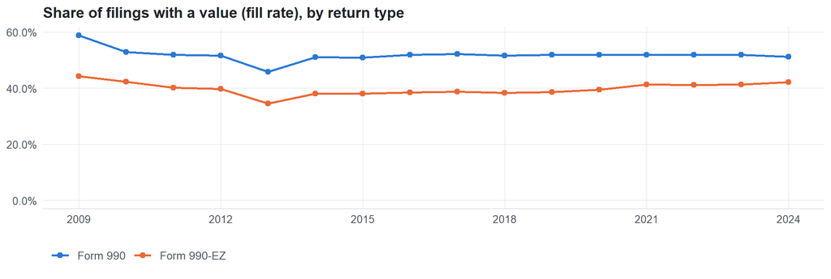

**Table view**

Table view: fill rate

| Tax year | Return type | Filings | All filings | Fill rate |
| --- | --- | --- | --- | --- |
| 2009 | Form 990 | 19,598 | 33,311 | 58.83% |
| 2009 | Form 990-EZ | 6,851 | 15,470 | 44.29% |
| 2010 | Form 990 | 64,979 | 123,025 | 52.82% |
| 2010 | Form 990-EZ | 26,775 | 63,326 | 42.28% |
| 2011 | Form 990 | 82,733 | 159,504 | 51.87% |
| 2011 | Form 990-EZ | 32,989 | 82,048 | 40.21% |
| 2012 | Form 990 | 92,832 | 179,688 | 51.66% |
| 2012 | Form 990-EZ | 37,180 | 93,750 | 39.66% |
| 2013 | Form 990 | 91,141 | 198,855 | 45.83% |
| 2013 | Form 990-EZ | 35,981 | 104,375 | 34.47% |
| 2014 | Form 990 | 111,707 | 218,619 | 51.10% |
| 2014 | Form 990-EZ | 44,256 | 116,417 | 38.02% |
| 2015 | Form 990 | 118,969 | 233,519 | 50.95% |
| 2015 | Form 990-EZ | 47,473 | 124,894 | 38.01% |
| 2016 | Form 990 | 126,371 | 243,903 | 51.81% |
| 2016 | Form 990-EZ | 50,255 | 130,484 | 38.51% |
| 2017 | Form 990 | 136,439 | 261,612 | 52.15% |
| 2017 | Form 990-EZ | 53,914 | 139,144 | 38.75% |
| 2018 | Form 990 | 140,147 | 271,442 | 51.63% |
| 2018 | Form 990-EZ | 57,221 | 149,384 | 38.30% |
| 2019 | Form 990 | 147,291 | 283,694 | 51.92% |
| 2019 | Form 990-EZ | 59,003 | 152,622 | 38.66% |
| 2020 | Form 990 | 166,145 | 320,342 | 51.86% |
| 2020 | Form 990-EZ | 67,017 | 169,864 | 39.45% |
| 2021 | Form 990 | 174,577 | 336,480 | 51.88% |
| 2021 | Form 990-EZ | 83,617 | 202,724 | 41.25% |
| 2022 | Form 990 | 181,002 | 349,055 | 51.85% |
| 2022 | Form 990-EZ | 84,841 | 206,130 | 41.16% |
| 2023 | Form 990 | 184,234 | 354,768 | 51.93% |
| 2023 | Form 990-EZ | 85,235 | 206,379 | 41.30% |
| 2024 | Form 990 | 141,742 | 277,298 | 51.12% |
| 2024 | Form 990-EZ | 75,247 | 178,867 | 42.07% |

## Repeating groups

Table cardinality in the concordance: **one**. 4 of 4 observed xpaths repeat within a filing.

Repeating element each xpath was observed in (from the raw indexed xpath)

| Xpath | Repeating element | Filings (summed over years) |
| --- | --- | --- |
| IRS990/StatesWhereCopyOfReturnIsFiled | (none) | 245932 |
| IRS990/StatesWhereCopyOfReturnIsFiled | IRS990/StatesWhereCopyOfReturnIsFiled | 14210 |
| IRS990EZ/StatesWhereCopyOfReturnIsFiled | (none) | 102631 |
| IRS990EZ/StatesWhereCopyOfReturnIsFiled | IRS990EZ/StatesWhereCopyOfReturnIsFiled | 1164 |
| IRS990/StatesWhereCopyOfReturnIsFldCd | (none) | 1616115 |
| IRS990/StatesWhereCopyOfReturnIsFldCd | IRS990/StatesWhereCopyOfReturnIsFldCd | 103658 |
| IRS990EZ/StatesWhereCopyOfReturnIsFldCd | (none) | 733726 |
| IRS990EZ/StatesWhereCopyOfReturnIsFldCd | IRS990EZ/StatesWhereCopyOfReturnIsFldCd | 10335 |

## Values

| Result | Check | Detail |
| --- | --- | --- |
| ✓ pass | Small code list | up to 71 distinct values per xpath and year |
| ✓ pass | Codes share one format | 100% have the shape AA |
| ✓ pass | Consistent letter case | 0.0% of values are lower case |

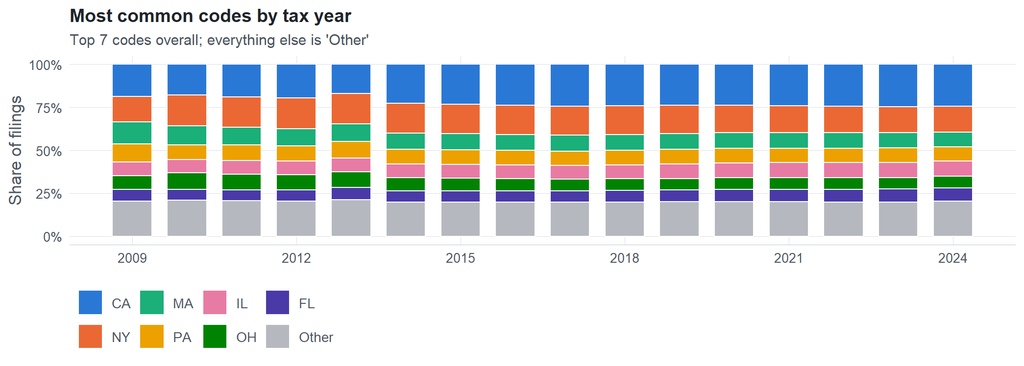

**Table view**

Table view: filings by code and tax year

| tax_year | CA | NY | MA | PA | IL | OH | FL | Other |
| --- | --- | --- | --- | --- | --- | --- | --- | --- |
| 2009 | 3,800 | 3,026 | 2,641 | 2,160 | 1,583 | 1,652 | 1,419 | 4,147 |
| 2010 | 11,881 | 11,880 | 7,381 | 5,780 | 4,945 | 6,419 | 4,320 | 13,899 |
| 2011 | 16,112 | 15,220 | 8,855 | 7,742 | 6,754 | 7,724 | 5,537 | 17,596 |
| 2012 | 19,019 | 17,279 | 9,630 | 8,784 | 7,762 | 8,357 | 6,346 | 19,933 |
| 2013 | 16,062 | 16,729 | 9,815 | 9,180 | 7,697 | 8,532 | 6,773 | 20,200 |
| 2014 | 27,090 | 20,474 | 11,177 | 10,293 | 9,487 | 9,215 | 7,696 | 23,735 |
| 2015 | 29,671 | 21,870 | 11,861 | 10,899 | 10,303 | 9,417 | 8,336 | 25,478 |
| 2016 | 32,515 | 23,212 | 12,442 | 11,731 | 10,953 | 9,736 | 8,726 | 27,165 |
| 2017 | 36,183 | 25,280 | 13,675 | 12,471 | 11,886 | 10,224 | 9,793 | 29,463 |
| 2018 | 37,488 | 26,295 | 14,207 | 13,080 | 12,630 | 10,572 | 10,482 | 31,084 |
| 2019 | 39,077 | 26,953 | 14,717 | 13,928 | 13,749 | 10,997 | 11,247 | 32,715 |
| 2020 | 43,421 | 28,951 | 16,310 | 15,404 | 15,815 | 12,383 | 12,894 | 36,473 |
| 2021 | 47,564 | 30,797 | 17,873 | 16,695 | 17,215 | 13,327 | 14,255 | 39,598 |
| 2022 | 49,536 | 31,470 | 18,213 | 17,293 | 17,788 | 13,643 | 14,954 | 40,721 |
| 2023 | 50,707 | 31,415 | 18,203 | 17,572 | 18,016 | 13,825 | 15,431 | 41,271 |
| 2024 | 39,631 | 24,583 | 13,636 | 13,628 | 14,197 | 11,229 | 12,368 | 33,153 |

Code frequencies (all xpaths, all years)

[output not shown]

## Examples

| Tax year | Return | Xpath | Organization | Value | Source |
| --- | --- | --- | --- | --- | --- |
| 2024 | 990 | IRS990/StatesWhereCopyOfReturnIsFldCd | GIRL SCOUTS OF KANSAS HEARTLAND INC | KS | [XML](https://gt990datalake-rawdata.s3.amazonaws.com/EfileData/XmlFiles/202630479349301123_public.xml) |
| 2024 | 990EZ | IRS990EZ/StatesWhereCopyOfReturnIsFldCd | WILD WEST WOMEN INC | CA | [XML](https://gt990datalake-rawdata.s3.amazonaws.com/EfileData/XmlFiles/202543179349205389_public.xml) |
| 2023 | 990 | IRS990/StatesWhereCopyOfReturnIsFldCd | SCENIC RIVERS LAND TRUST INC | MD | [XML](https://gt990datalake-rawdata.s3.amazonaws.com/EfileData/XmlFiles/202403109349303230_public.xml) |
| 2023 | 990EZ | IRS990EZ/StatesWhereCopyOfReturnIsFldCd | KNIGHTS OF PYTHIAS OF CALIFORNIA - | CA | [XML](https://gt990datalake-rawdata.s3.amazonaws.com/EfileData/XmlFiles/202500649349200835_public.xml) |
| 2022 | 990 | IRS990/StatesWhereCopyOfReturnIsFldCd | THE DHARMA PROJECT INC | GA | [XML](https://gt990datalake-rawdata.s3.amazonaws.com/EfileData/XmlFiles/202311579349300121_public.xml) |
| 2022 | 990EZ | IRS990EZ/StatesWhereCopyOfReturnIsFldCd | Dana Point Post 9934 Veterans of Foreign Wars | CA | [XML](https://gt990datalake-rawdata.s3.amazonaws.com/EfileData/XmlFiles/202342379349201129_public.xml) |
| 2021 | 990 | IRS990/StatesWhereCopyOfReturnIsFldCd | SCRANTON NEIGHBORHOOD HOUSING | PA | [XML](https://gt990datalake-rawdata.s3.amazonaws.com/EfileData/XmlFiles/202330939349300318_public.xml) |
| 2021 | 990EZ | IRS990EZ/StatesWhereCopyOfReturnIsFldCd | SOMERSET AREA MINISTRIES INC | PA | [XML](https://gt990datalake-rawdata.s3.amazonaws.com/EfileData/XmlFiles/202202039349200010_public.xml) |
| 2020 | 990 | IRS990/StatesWhereCopyOfReturnIsFldCd | SANTE HEALTH FOUNDATION | CA | [XML](https://gt990datalake-rawdata.s3.amazonaws.com/EfileData/XmlFiles/202242719349301869_public.xml) |
| 2020 | 990EZ | IRS990EZ/StatesWhereCopyOfReturnIsFldCd | STREETLIGHT CHRISTIAN MINISTRIES | CA | [XML](https://gt990datalake-rawdata.s3.amazonaws.com/EfileData/XmlFiles/202102519349200325_public.xml) |
| 2019 | 990 | IRS990/StatesWhereCopyOfReturnIsFldCd | PROJECT KENYA INC | TN | [XML](https://gt990datalake-rawdata.s3.amazonaws.com/EfileData/XmlFiles/202013079349301106_public.xml) |
| 2019 | 990EZ | IRS990EZ/StatesWhereCopyOfReturnIsFldCd | FORT FREDERICA ASSOCIATION INC | GA | [XML](https://gt990datalake-rawdata.s3.amazonaws.com/EfileData/XmlFiles/202110349349200601_public.xml) |

## Reviewer checklist

- The definition matches the form line and instructions for every xpath’s schema years.
- Every xpath pooled here measures the same thing on the 990 and 990-EZ (close enough for analysis).
- The coverage chart has no unexplained gaps or jumps between tax years.
- Each open flag is fixed, or accepted with a note in validation_log.csv.
- Every code is valid for the list the form uses (state, country, valuation method, …).
- The code list and its meaning did not change across schema versions.
- Codes are stored as text, so values like leading zeros are preserved.

Record the review as a row in `inst/extdata/src/validation_log.csv` (variable_name, reviewer, date, status, note). Evidence built 2026-09-23 17:09:04 MST from the ef2 DuckDB builds, TY2009–2024.